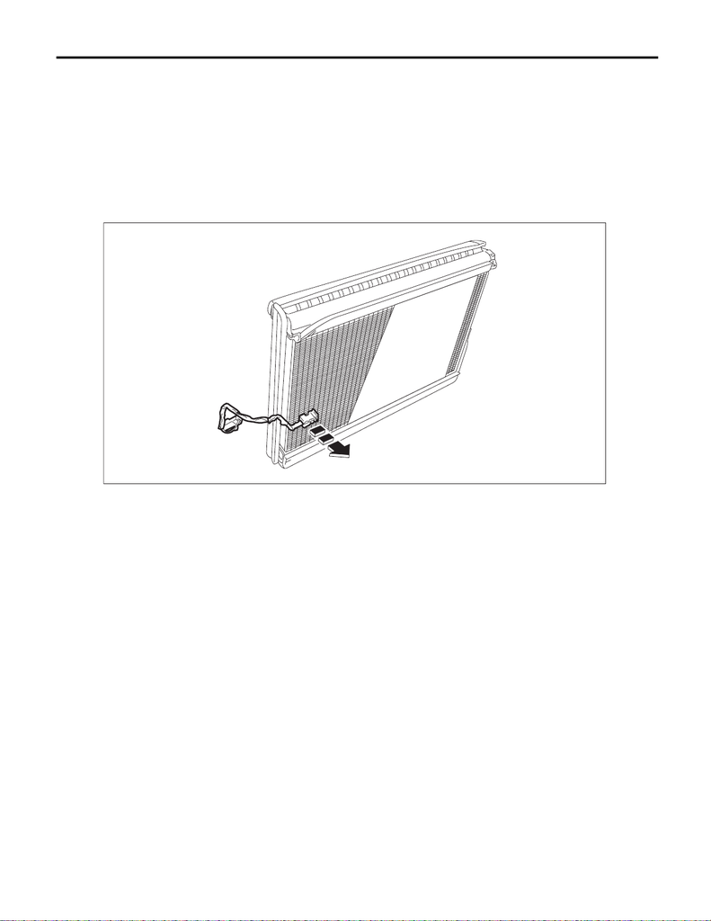

AC-80

Evaporator Sensor

HVAC SYSTEM (HEATER, VENTILATOR AND A/C)

24.Evaporator Sensor

A: REMOVAL

1) Using the refrigerant recovery system, discharge refrigerant. <Ref. to AC-26, PROCEDURE, Refrigerant

Recovery Procedure.>

2) Disconnect the ground cable from battery. <Ref. to NT-5, BATTERY, NOTE, Note.>

NOTE:

For models other than STI model, disconnect the ground terminal from battery sensor.

3) Remove the evaporator assembly - cooling. <Ref. to AC-57, REMOVAL, Evaporator.>

4) Remove the thermostat - cooling.

AC-02705

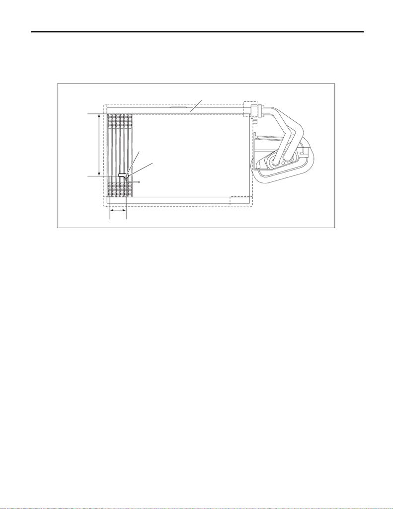

AC-81

Evaporator Sensor

HVAC SYSTEM (HEATER, VENTILATOR AND A/C)

B: INSTALLATION

CAUTION:

• Make sure that the water seal packing on the cover attachment area is securely attached.

• Replace the O-rings with new parts, and then apply compressor oil.

1) Install the thermostat - cooling at the position shown in the figure below.

2) Install the evaporator assembly - cooling. <Ref. to AC-60, INSTALLATION, Evaporator.>

3) Connect the battery ground terminal. <Ref. to NT-5, BATTERY, NOTE, Note.>

NOTE:

For models other than STI model, connect the ground terminal to battery sensor.

4) Charge refrigerant. <Ref. to AC-27, PROCEDURE, Refrigerant Charging Procedure.>

(1) Evaporator ASSY - cooling (3) Thermostat - cooling (5) Fifth row fin from the left end

(2) Center (4) 130 mm (5.12 in) from the upper

end of the fins

AC-02718

(4)

(5)

(1)

(2)

(3)

[figure not shown]

AC-82

Evaporator Sensor

HVAC SYSTEM (HEATER, VENTILATOR AND A/C)

C: INSPECTION

1) Prepare the vehicle.

NOTE:

Check that the ambient temperature is 25 — 40°C (77 — 104°F) and that the humidity is 30% — 80%.

• Place the vehicle in the workshop or in the shade and windless condition.

• Open all windows.

2) Set the vehicle to the following conditions.

3) Using the Subaru Select Monitor, check «Evaporator Temperature».

Preparation tool:

Subaru Select Monitor III kit

NOTE:

For detailed procedures, refer to “PC application help for Subaru Select Monitor”.

(1) Idle the engine for 15 minutes, and then compare the air flow outlet temperature with «Evaporator

Temperature».

Preparation tool:

Thermometer and hygrometer

NOTE:

For outlet opening temperature, measure the average temperature of center grille assembly and side grille

assembly.

(2) Do the air flow outlet temperature and «Evaporator Temperature» differ by 3°C (5.4°F) or more?

• Yes → Go to step 4).

• No → Evaporator sensor is normal.

Item Condition

Engine Idling

Air vent grille Shutter is fully open.

A/C switch OFF

Temperature adjustment dial LO (MAX COOL)

FRESH/RECIRC switch CIRC

Air flow control dial or switch VENT

Fan dial 5/7 level

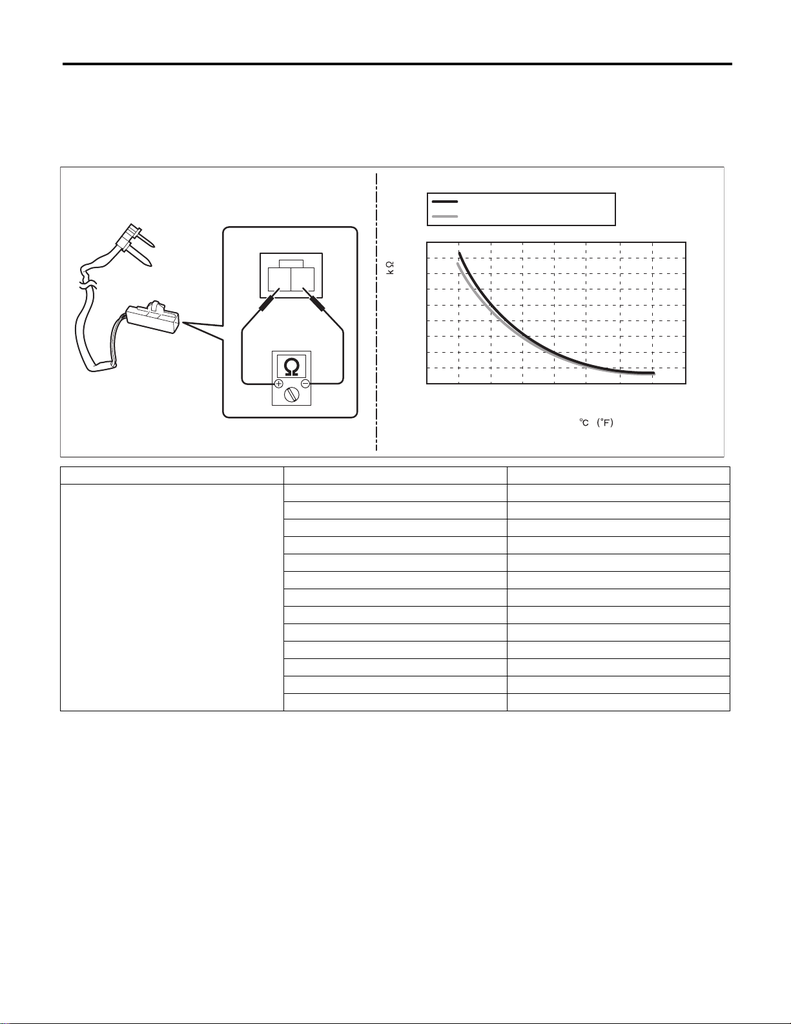

AC-83

Evaporator Sensor

HVAC SYSTEM (HEATER, VENTILATOR AND A/C)

4) Check the evaporator sensor.

(1) Disconnect the connector.

(2) Measure the resistance between connector terminals.

Preparation tool:

Circuit tester

(3) Replace the evaporator sensor if the inspection result is not within the standard value.

Terminal No. Inspection conditions Standard

1 — 2

-20°C 15.37 — 16.62 kΩ

-15°C 12.09 — 12.87 kΩ

-10°C 9.576 — 10.05 kΩ

-5°C 7.636 — 7.899 kΩ

0°C 6.132 — 6.256 kΩ

5°C 4.891 — 5.057 kΩ

10°C 3.928 — 4.113 kΩ

15°C 3.174 — 3.366 kΩ

20°C 2.581 — 2.77 kΩ

25°C 2.111 — 2.292 kΩ

30°C 1.737 — 1.907 kΩ

35°C 1.437 — 1.595 kΩ

40°C 1.195 — 1.34 kΩ

2

1

AC-02729

18.00

16.00

14.00

12.00

10.00

8.00

6.00

4.00

2.00

0.00

(-32)

(-4)

: STANDARD (MIN TOLERANCE)

: STANDARD (MAX TOLERANCE)

RESISTANCE VALUE

TEMPERATURE